# Implementazione Parallela dell’Automa Cellulare Game of Life in C++ e OpenMP

Elias Ezequiel Moreno matricola n° 244211

Il gioco della Vita di John Conway è un modello di automa cellulare. Questo “gioco” si svolge in una griglia quadrata NxN, composta da celle che possono assumere solo due stati: 0 (la cellula è morta) o 1(la cellula è viva). Lo stato della griglia evolve in un tempo discreto, con una separazione netta tra lo stato precedente e quello successivo. Il valore di ogni cella varia a seconda dello stato attuale delle celle adiacenti ad essa, seguendo le seguenti regole:

- Qualsiasi cella viva con meno di due celle vive adiacenti muore -> effetto d’isolamento;
- Qualsiasi cella viva con due o tre celle vive adiacenti sopravvive alla generazione successiva;
- Qualsiasi cella viva con più di tre celle vive adiacenti muore -> effetto sovrappopolazione;
- Qualsiasi cella morta con esattamente tre celle vive adiacenti diventa una cella viva -> effetto di riproduzione.

### Studio delle performance al variare della dimensione del problema da risolvere

L’analisi delle performance viene svolta confrontando i risultati ottenuti dal codice in sequenziale con quelli della versione in parallelo. Il numero di thread viene imposto pari al numero di core presenti nel dispositivo, le iterazioni pari a 100 e lo scheduling di tipo statico:

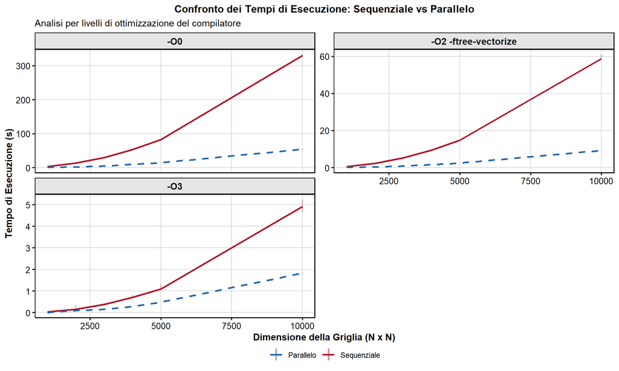

Analizzando il grafico, emerge chiaramente come il parallelismo rappresenti uno strumento fondamentale per l’abbattimento dei tempi di calcolo. Il vantaggio computazionale offerto dall’architettura multi-thread si manifesta in modo proporzionale alla dimensione del dominio: all’aumentare della complessità della griglia ($N \times N$), le curve divergono significativamente. Questo dimostra che il parallelismo esprime il suo massimo potenziale sui carichi di lavoro più intensivi, dove il tempo risparmiato nella divisione del calcolo supera ampiamente l’overhead introdotto dalla gestione dei thread.

### Studio della variazione delle performance in base alla variazione del parallelismo

#### Strong Scaling

Le perfomance del nostro codice possono variare non solo in base a come le istruzioni vengono processate (sequenziale o parallelo) ma anche in base a come esse sono distribuite. Questo fattore è in grado di essere regolato in base al numero di thread definiti dall’utente. Aumentare il numero di thread non sempre comporta l’aumento delle perfomance dato che, se aumentati oltre un certo limite può avvenire il fenomeno chiamato *overhead* di gestione, dove l’elevato numero di thread genera una contesa nelle risorse del computer, provocando una riduzione nell’efficienza.

il test è stato svolto con una matrice 10000x10000, *scheduling* statico e come tempo di esecuzione in sequenziale quello ricavato dalle prove precedenti.

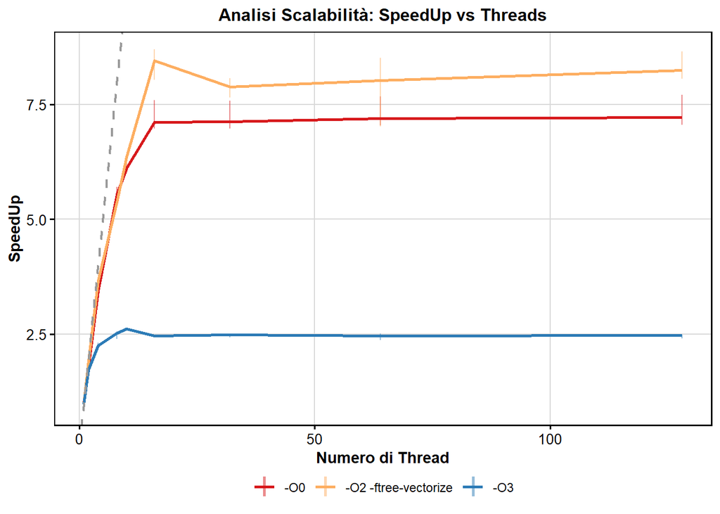

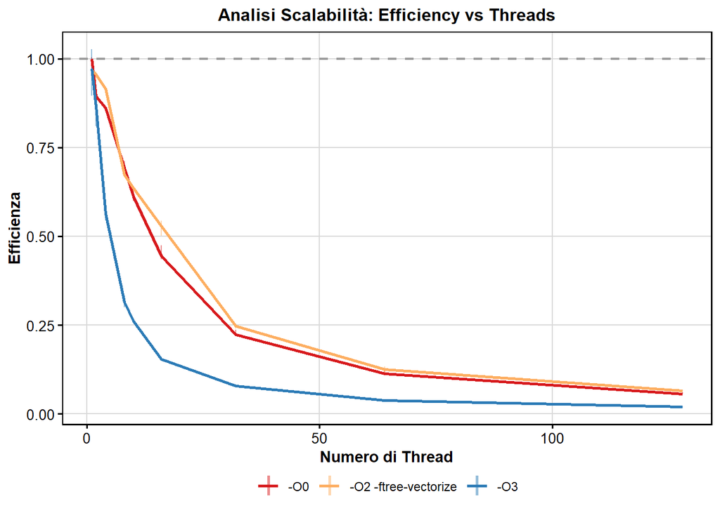

Dal grafico dell’efficienza si ricava come questa si riduca drasticamente man mano che il numero di thread aumenta fino a quando il valore non è prossimo a zero, dimostrando che *l’OverThreading* frazioni il lavoro del singolo thread, riducendo quindi il tempo di esecuzione dei processi, aumentando di contro i tempi di lettura e scrittura a causa del *thread overhead* e al *Bus Contention*.

#### Weak Scaling

facendo un analisi del weak scaling, vogliamo valutare l’efficienza di ciascun thread, aumentando il numero di thread ma mantenendo fisso il carico di lavoro per ciascuno di esso. Nel caso studiato, si fornisce ad ogni *thread* lo studio di 25 milioni di celle, ossia una matrice 5000x5000(se consideriamo 4 thread, il carico di lavoro deve rimanere costante, perciò il la matrice passa da 5000x5000 a 10000x10000). In un caso ideale, il tempo di esecuzione del programma dovrebbe mantenersi invariato, poiché il carico di lavoro associato a ciascun thread rimane fisso. Quello che risulterà invece è una limitazione di questa scalabilità dovuta alla **Banda passante della Memoria** ed all’**Overhead di Sincronizzazione**.

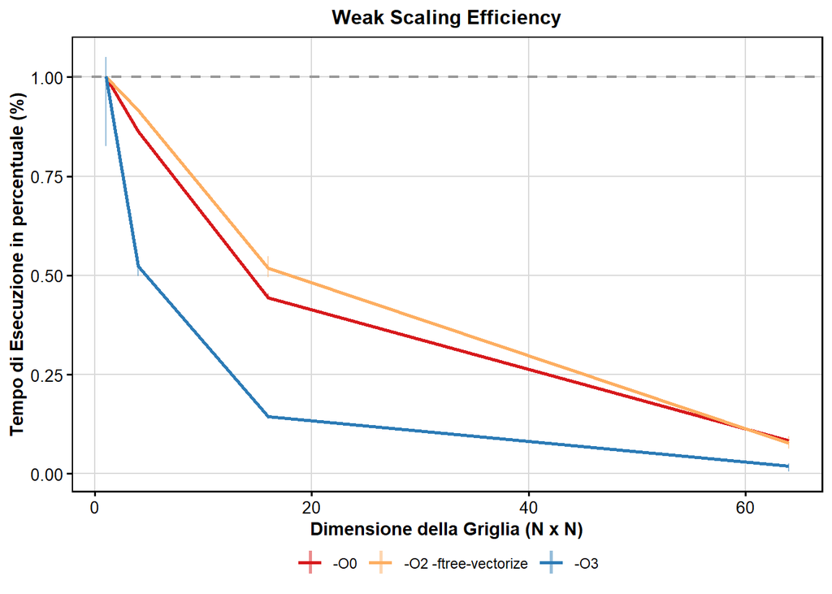

### Studio della variazione delle performance in base alla tipologia di **variabili** e lo **Scheduling** dei threads

#### Private vs Shared

In un ambiente di calcolo parallelo, la corretta classificazione delle variabili è importante per garantire correttezza matematica della simulazione ed efficienza del codice stesso. In OpenMp, la memoria viene gestita attraverso due classi principali:

- **Condivisa** (shared): sono le variabili a cui posso avere accesso tutti i thread attivi contemporaneamente. Nel nostro codice, le variabili condivise sono la dimensione N, e gli stati CurrentGen e NextGen. Siccome ogni thread elabora celle distinte e indipendenti, non si verifica alcun conflitto. Usare variabili condivise permette di evitare che inutili copie vengano fatte durante l’esecuzione del programma, evitando quindi il più possibile i tempi di scrittura e lettura, ossia i più lenti.
- **Privata**(Private): sono le variabili che ciascun thread ha, il cui valore dev’essere indipendente dall’azione degli altri thread. Affinché l’algoritmo funzioni correttamente, indici di scorrimento come x,ydx e dy, e le variabili temporanee come Alive e CurrentState, devono essere private. Questo perché se fossero condivise, ogni thread sarebbe in grado di sovrascrivere tale valore, portando a perdite di informazioni a “salti” o sovrascritture della variabile, causando quindi un’avanzamento errato dell’algoritmo che porta ad un risultato non concorde

Una prova interessante da compiere per capire cosa potrebbe accadere in caso di un’errata configurazione di variabili condividise e private è quella di forzare il codice a identificare CurrentGen come variabile privata. Quello che potremmo dedurre che accada è che il programma andrà a generare una griglia per ciascun thread, aumentando i tempi di lettura e di scrittura complessivi, senza contare l’utilizzo della RAM.

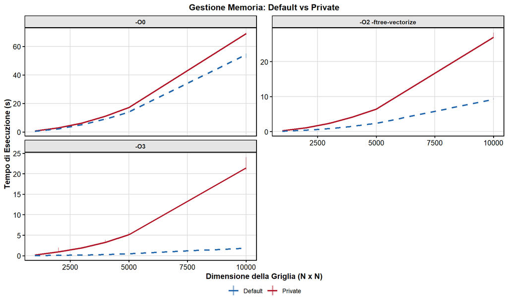

#### Static vs Dynamic vs Guided

Lo *Scheduling* è un altro requisito importante per l’efficienza di un programma. il processo mediante il quale un sistema decide l’ordine di esecuzione, assegnando le risorse necessarie. Si divide principalmente in due approcci, che si differenziano in base al momento in cui vengono fatte tali decisioni:

- **Statico**(Static Scheduling): l’assegnazione delle risorse viene decisa prima dell’esecuzione del programma. Questo permette di migliorare l’overhead ma manca assolutamente di flessibilità.
- **Dinamico**(Dynamic Scheduling): le risorse vengono assegnazte durante l’esecuzione del programma, permettendo quindi maggiore flessibilità in caso di variazione del carico di lavoro, aumentando il tempo di esecuzione del programma.
- **Guidato**(Guided Scheduling): le risorse vengono assegnate durante l’esecuzione in blocchi (chunk) di dimensioni via via decrescenti fino a un limite minimo prefissato, permettendo di mantenere l’alta flessibilità ai carichi di lavoro variabili ma riducendo drasticamente il tempo di overhead (sincronizzazione) rispetto al dinamico puro.

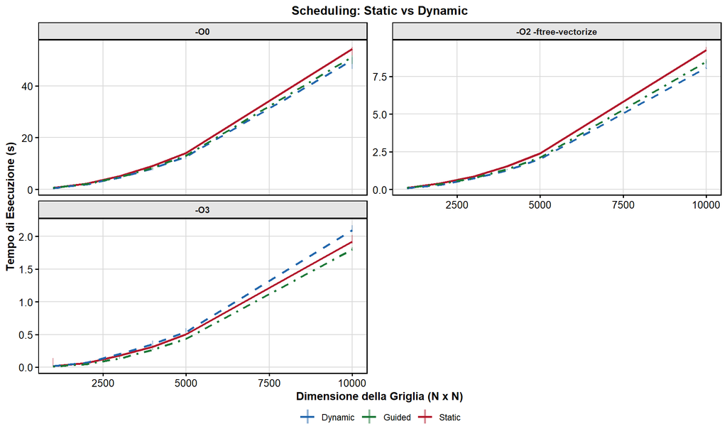

### Analisi in base all’inizializzazione delle Griglie (1D vs 2D)

L’obiettivo di questo studio è analizzare come le performance del programma variano in base all’architettura della griglia. In particolare si analizzano due configurazioni diverse di griglia:

- **Vettore monodimensionale**: La griglia viene vettorizzata, distribuendo le righe, risultando in un singolo vettore unico. In questo caso per spostarsi all’interno del vettore si usa l’indice “y*N + x”
- **Matrice bidimensionale**: si usa una sintassi più naturale e per muoversi usiamo separatamente gli indici “x ed y”

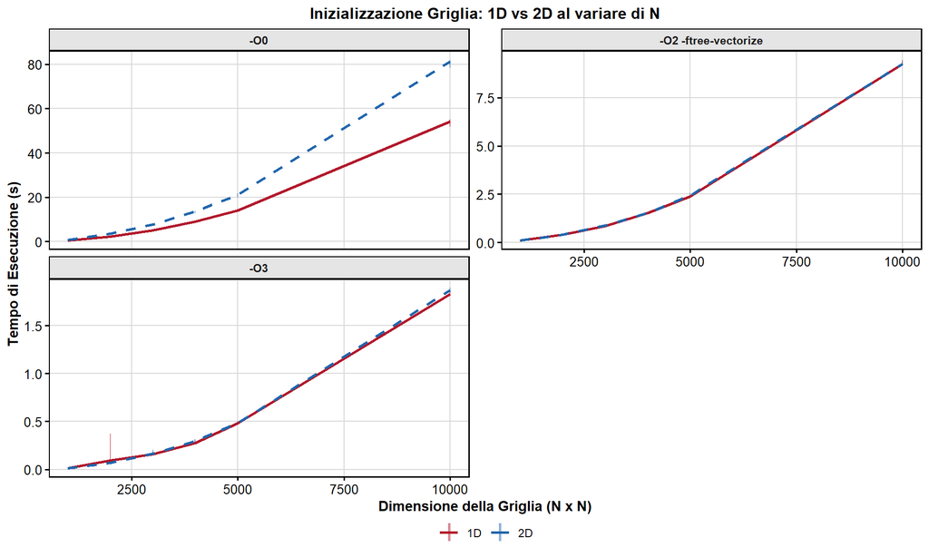

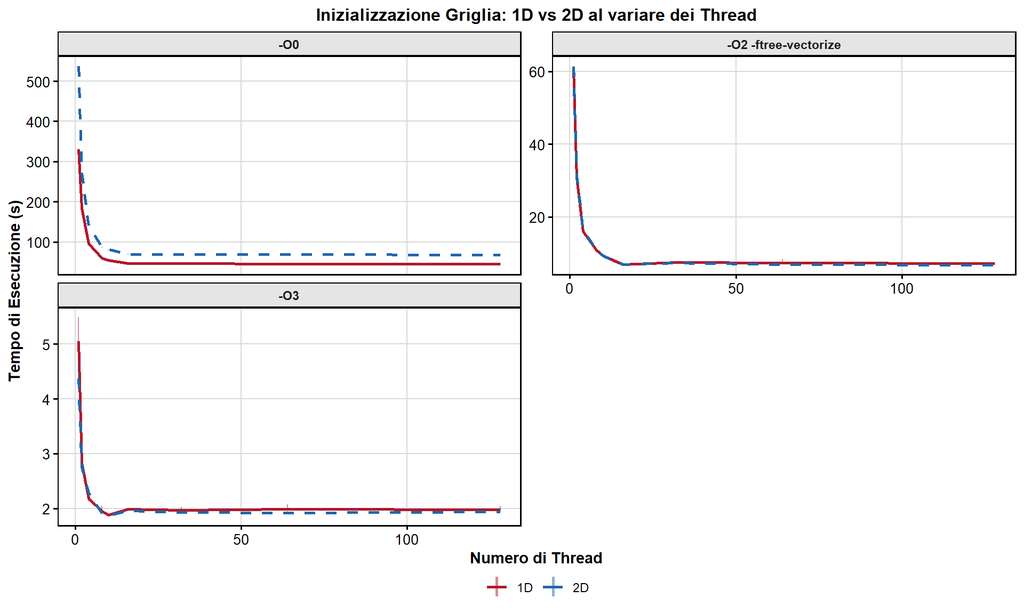

### Analisi finale

La configurazione utilizzata per l’analisi prestazionale definitiva rappresenta la sommatoria di tutti gli studi svolti antecedentemente. Al fine di ridurri al massimo il tempo di esecuzione del programma, l’implementazione finale integra: * L’uso del flag -O3 -native: permette al compilatore di lavorare al massimo delle capacità del computer su cui è stato generato * L’uso di guided anziché static: permette di ottenere risultati migliori data la maggiore flessibilità del programma in caso di rumori imprevisti. Questa scelta si può confermare osservando le analisi svolte precedentemente.

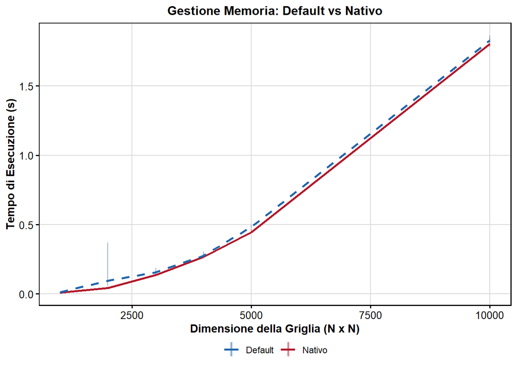

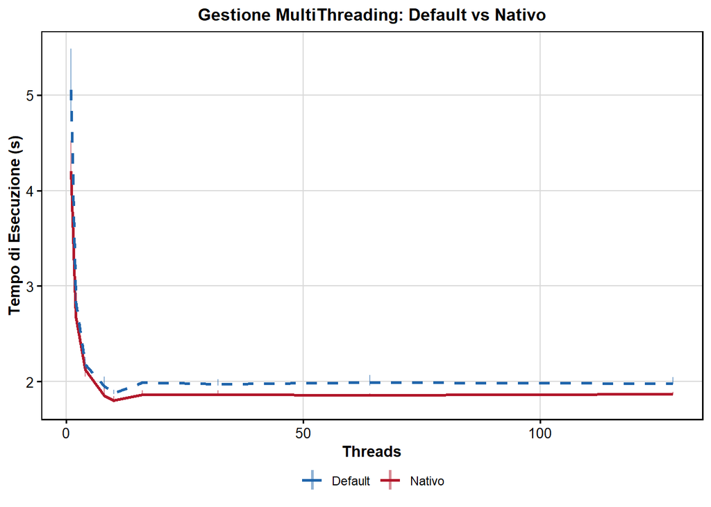

Analizzando i grafici si può notare come l’aggiunta della *flag* nativo abbia ridotto, seppur non drasticamente, il tempo di esecuzione in maniera costante e apprezzabile. Il motivo dietro al divario prestazionale poco marcato è dovuto principalmente ad un limite intrinseco del sistema:**le operazioni di scrittura e lettura in RAM**. Essendo questo problema di *Memory-Bound* molto significativo sulle prestazioni del programma, le ottimizzazioni della CPU finiscono per essere rallentantate dalla banda passante della RAM, causando un ridotto guadagno temporale. Questo riscontro è comunque positivo, perché va ad confermare il raggiungimento del limite massimo prestazionale dell’hardware considerato.